# Incident analysis based on MITRE standards

Marc Santasusagna

11/06/2021

# Introducción

Com a membre de l’equip de CYBERSEGURETAT i expert en data science, es sol·licita la teva col·laboració per a l’anàlisi d’un conjunt d’incidents de seguretat afegint informació de context, de manera que pugui ajudar a entendre que va succeir i com millorar.

## Objetivo

L’objectiu de la present pràctica és realitzar un estudi d’un seguit d’incidents que s’han identificat en diferents empreses per poder determinar qui els ha produït així com investigar de quina manera s’han pogut realitzar per a futures prevencions.

Per tal de poder dur a terme aquest estudi, s’han proporcionat un grup de datasets. D’una banda, es posseeix la informació dels incidents a estudiar i, de l’altra, la informació d’un seguit d’estàndards que ens ajudaran a comprendre i posar en context tals incidents per finalment, extraure un seguit de conclusions.

S’han seguit els següents passos per tal d’obtenir l’entorn preparat i començar l’anàlisi del conjunt d’incidents: * 1. En primer lloc, s’ha descarregat tot el respositori de github: https://github.com/humbertcostas/DDSreport i s’ha descomprimit el contingut en una carpeta al local. * 2. S’hauria d’haver obert un projecte (.rproj) nou a RStudio però en aquest cas s’utilitzarà la plantilla de la pràctica amb extensió rmd, que posteriorment es publicarà en format HTML. * 3. Importar els diferents conjunts de dades (datasets) que es localitzen dins de la carpeta data-raw. * 4. En aquest punt, un cop es normalitzin i sanegin les ades, ja es pot començar a fer l’anàlisi de d’aquestes i extreure conclusions.

# Data sets

```r
raw_incidents <- readRDS(file = "data/incidents.rds")
source("data-raw/mitre-cwe.R")
source("data-raw/nist-cve.R")
```

[output not shown]

[output cut: 25 more lines]

```r
source("data-raw/mitre-attck.R")
source("data-raw/mitre-shield.R")
```

```
## RJSONIO not loaded
```

```r
source("data-raw/mitre-car.R")
```

# Packages

```r
suppressPackageStartupMessages(library("dplyr"))
library("tidyr")
suppressPackageStartupMessages(library("DataExplorer"))
library("ggridges")
library("ggplot2")
suppressPackageStartupMessages(library("hrbrthemes"))
suppressPackageStartupMessages(library("viridis"))
library(knitr)
library(markdown)
```

## 1. Anàlisi inicial dataset incidents

Per començar, es realitza un anàlisi inicial del nostre dataset d’incidents per tal de veure quin tipus d’informació s’està treballant. Mitjançant funció summary() es pot veure un recull estadístic inicial del dataset d’incidents. No obstant, prèviament s’han de normalitzar les dades del dataset: * 1. S’extrauen les tres columnes de mitre_attack i s’engloben dins del dataframe incidents per treballar en un mateix dataframe o conjunt de dades. * 2. S’enumeren els valors únics per grup en el dataset i les columnes que presenten informació en forma de matriu, es transformen en dataset per poder treballar en les mateixes condicions. * 3. Es converteixen totes les columnes de caràcters en factors.

```r
incidents <- readRDS(file = "data/incidents.rds")
incidents <- incidents %>% unnest(mitre_attack);
apply(incidents, 2, function(x) length(unique(x)))
```

```
## first_event_ts first_alert_ts containment_ts            org         tactic
##            376            378            381            167              9
##      technique             id       industry
##             28             28             19
```

```r
incidents <- incidents %>%
  mutate_if(is.character, as.factor)
#S'eliminen els dulpicats
incidents_final <- dplyr::distinct(incidents);

summary(incidents_final)
```

```
##  first_event_ts                first_alert_ts
##  Min.   :2019-01-09 13:06:03   Min.   :2019-01-09 13:06:03
##  1st Qu.:2019-05-10 21:18:02   1st Qu.:2019-05-10 21:19:01
##  Median :2019-06-25 11:31:05   Median :2019-06-25 19:58:03
##  Mean   :2019-06-30 07:56:59   Mean   :2019-06-30 10:19:31
##  3rd Qu.:2019-08-29 13:17:05   3rd Qu.:2019-08-29 13:34:05
##  Max.   :2019-09-30 20:44:00   Max.   :2019-09-30 20:44:01
##
##  containment_ts                      org                      tactic
##  Min.   :2019-04-01 12:19:24   8922d54f: 19   Execution          :288
##  1st Qu.:2019-05-13 20:04:59   ccf43f76: 14   Initial Access     :138
##  Median :2019-06-28 07:40:14   10cc3cd8: 13   Defense Evasion    : 23
##  Mean   :2019-07-02 09:49:40   4b8b9b94: 12   Persistence        : 15
##  3rd Qu.:2019-08-29 14:43:28   5aa2992c: 12   Collection         :  9
##  Max.   :2019-09-30 21:13:48   b52887d2: 11   Command and Control:  9
##                                (Other) :408   (Other)            :  7
##                 technique         id               industry
##  Third-Party Software:136   T1072  :136   Manufacturing: 77
##  Valid Accounts      : 79   T1078  : 79   Finance      : 66
##  PowerShell          : 69   T1086  : 69   Professional : 62
##  Spearphishing Link  : 55   T1192  : 55   Information  : 61
##  User Execution      : 47   T1204  : 47   Retail       : 50
##  Scripting           : 22   T1064  : 22   Trade        : 32
##  (Other)             : 81   (Other): 81   (Other)      :141
```

Aquí ja podem extreure dades interessants, com que la tàctica més utilitzada és **Execution** seguidament de **Inicial Access** o que el sector més afectat és el de **Manufacturing** tal i com es mostra a continuació:

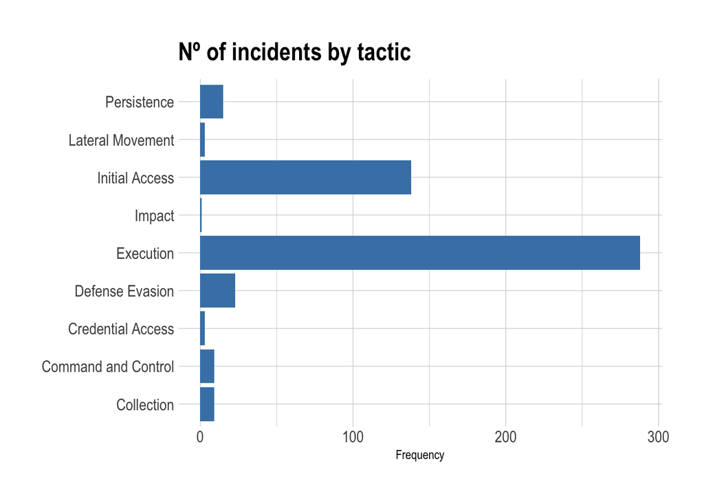

```r
incidents_bytactic <- table(incidents_final$tactic)
bytactic <- as.data.frame(incidents_bytactic) %>%
arrange(desc(Freq));

colnames(bytactic) <- c("Tactiques", "Freqüència")

p <- ggplot(bytactic, aes(x=Tactiques, y=Freqüència)) +
  geom_bar(stat = "identity", fill="steelblue") +
  ggtitle("Nº of incidents by tactic") +
  xlab("Tactic") + ylab("Frequency")
p + theme() +
coord_flip() +
  theme_ipsum() +
  theme(axis.title.y = element_blank())+
  theme(axis.title.x =  element_text(angle = 0, hjust = 0.5))
```

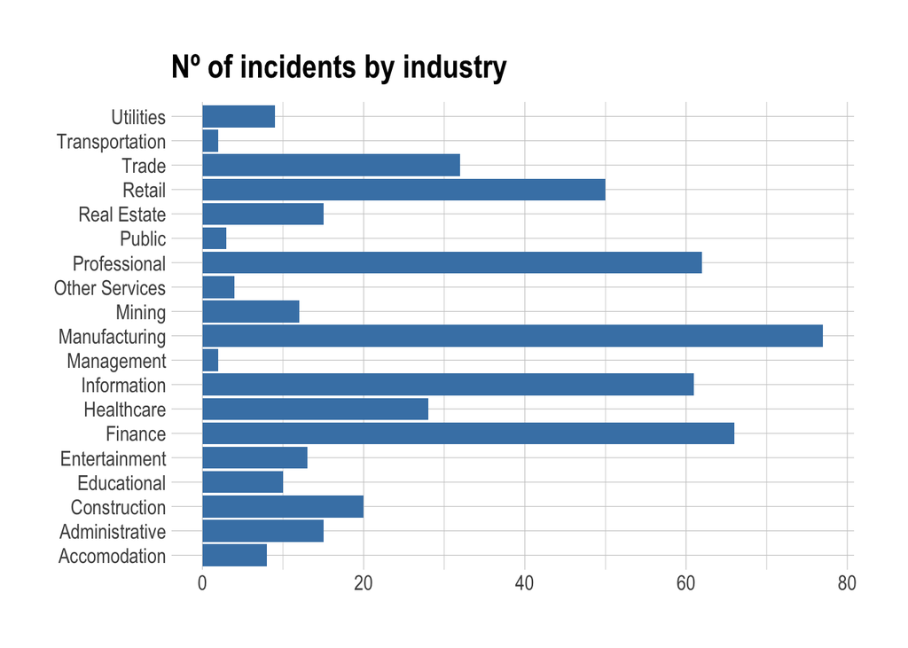

```r
incidents_byind <- table(incidents_final$industry)
byind <- as.data.frame(incidents_byind) %>%
arrange(desc(Freq));

ggplot(byind, aes(x=Var1, y=Freq)) +
  geom_bar(stat = "identity", fill="steelblue") +
  ggtitle("Nº of incidents by industry") +
  xlab("Dose (mg)") + ylab("Teeth length") +
  coord_flip() +
  theme_ipsum() +
  theme(axis.title.x = element_blank())+
  theme(axis.title.y = element_blank())
```

Concretament, s’observa que els sectors que han patit més atacs són *Manufacturing*, *Finance* i *Professional*.  
## 2. ¿Quants incidents estan relacionats amb phishing?

Es realitza el gràfic on es mostren totes les tècniques utilitzades i la seva freqüència. **Un cop s’ha normalitzat el dataset d’incidents i s’han eliminat els duplicats, el número total d’incidents relacionats amb phishing s’eleva a 55.**. No obstant, s’observa que la tècnica més utilizada amb diferencia és **Third-Party Software** representant quasi el 28% del total de la mostra. Les 4 tècniques següents (per ordre de freqüència): **Valid Accounts**, **PowerShell**, **Spearphishing** i **User Execution** representen, en conjunt, el 51% de tècniques més utilitzades. La resta, suposa un percentatge molt baix (entre el 1-4% del total).

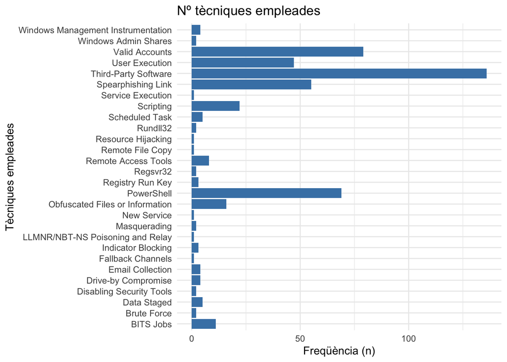

```r
incidents_techniques <- incidents_final %>%
  count(technique) %>%
 arrange(desc(n))

incidents_phishing<-ggplot(data=incidents_techniques, aes(x=n, y=technique)) +
  geom_bar(stat="identity", fill="steelblue")+
  ggtitle("Nº tècniques empleades") +
  xlab("Freqüència (n)") + ylab("Tècniques empleades") +
  theme_minimal()


incidents_phishing
```

També es pot relacionar el top 5 de tècniques més utilitzades pels ciberdelinqüents amb la seva **tècnica id**, tal com mostra el gràfic següent. Així doncs, el present estudi es centrarà en aquestes 5 de tècniques: **T1072**, **T1078**, **T1086**, **T1192** i **T1204**.

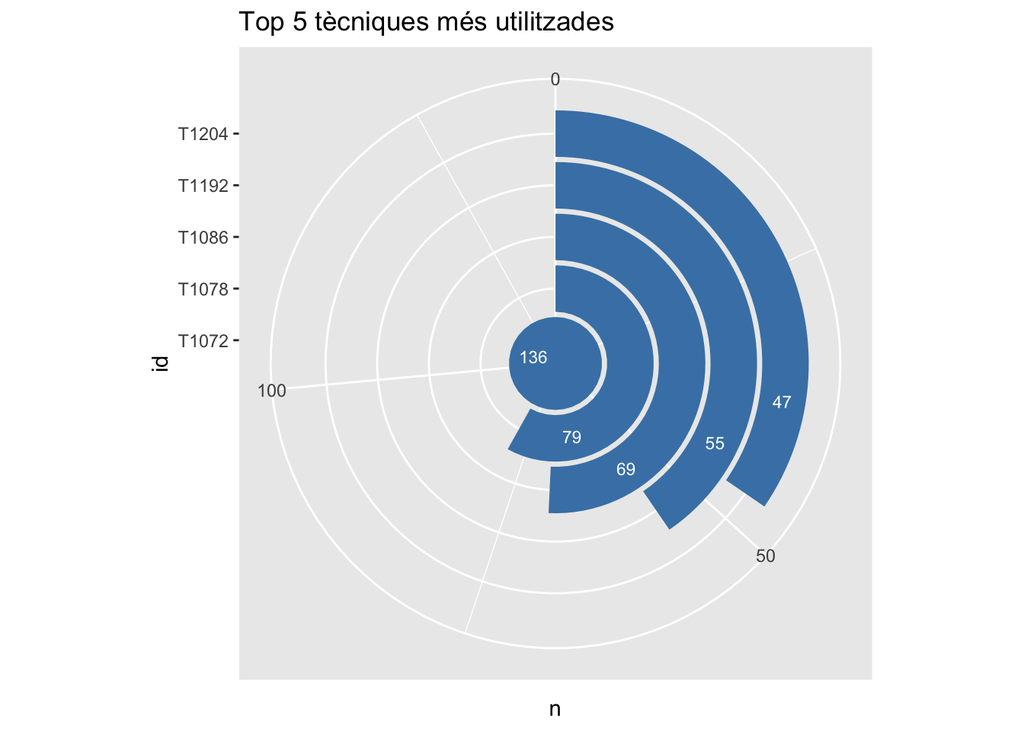

```r
incidents_techniques_id <- incidents_final %>%
  select(id, technique) %>%
  count(id) %>%
   arrange(desc(n)) %>%
  head(5);

library(ggplot2)
ggplot(incidents_techniques_id,aes(x=id,y=n))+
  geom_bar(stat = "identity",
           fill="steelblue")+
    ggtitle("Top 5 tècniques més utilitzades") +
    geom_text(aes(label=n),
    position=position_stack(vjust=0.8),color="white",size=3)+
    coord_polar(theta = "y")
```

*Actualització: Per manca de temps i per les posteriors relacions establertes, l’estudi es centrarà en les dues tècniques més freqüents dels atacs dels ciberdelinqüents: T1072 i T1078*.  
## 3. ¿Quins estàndards podrien afegir context als incidents?

#### CWE

El CWE és un conjunt unificat i mesurable de vulnerabilitats de software, principalment relacionades amb l’arquitectura i el disseny, que permet la discussió, descripció i enumeració d’aquestes així com també els errors de codificació i disseny de baix nivell

```r
raw_cwes <- bind_rows(cwe.weaknesses, cwe.categories, cwe.views)
cwe_1 <- raw_cwes %>%
  select(ID, Abstraction, Structure, Status, CWE_Type, Code_Standard, Likelihood_Of_Exploit, Potential_Mitigations, Detection_Methods) %>%
#sapply(cwe_1, function(x) sum(is.na(x)))
na.omit;
```

S’observa una columna interessant, la de la probabilitat (alta, mitjana o baixa) que una vulnerabilitat sigui explotada. Així, s’agrupa el nombre total de vulnerabilitats en les seves diferents probabilitats a ser explotades. El resultat s’emmagatzema a un nou dataset: *cwe_2*.

```r
cwe_2 <- cwe_1 %>%
  group_by(Likelihood_Of_Exploit) %>%
  summarise(nº = n());
```

Finalment, es procedeix a visualitzar les dades resultants en el següent gràfic:

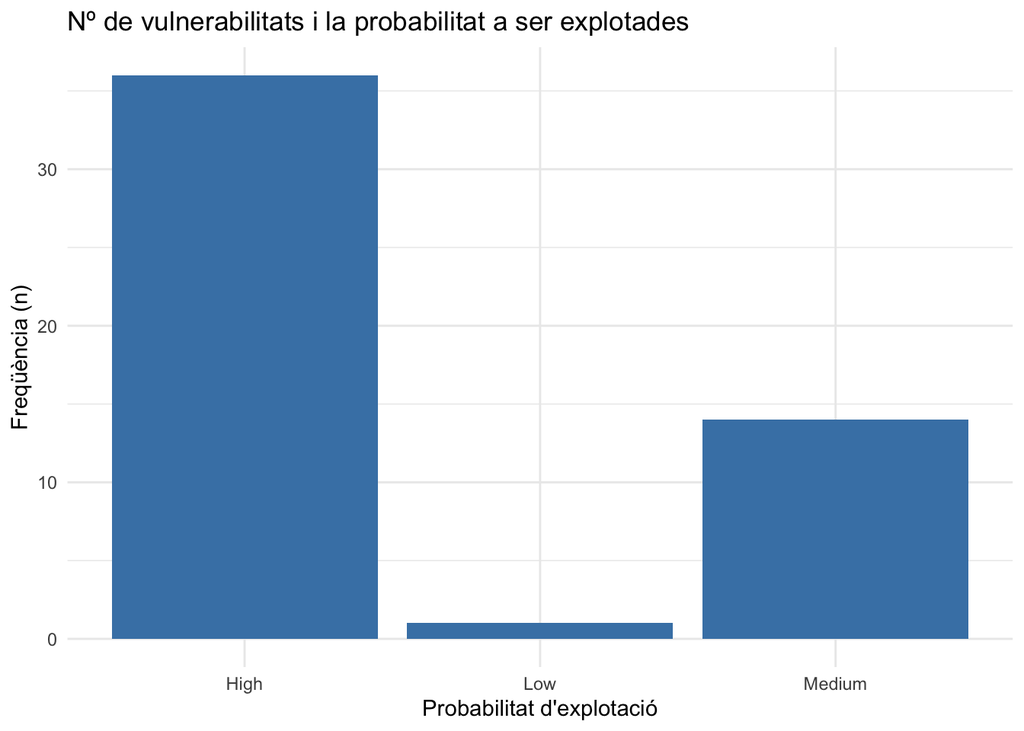

```r
df_cwe_plot <-ggplot(cwe_2, aes(x=Likelihood_Of_Exploit, y=nº)) +
  geom_bar(stat="identity", fill="steelblue")+
  ggtitle("Nº de vulnerabilitats i la probabilitat a ser explotades") +
  xlab("Probabilitat d'explotació") + ylab("Freqüència (n)") +
  theme_minimal()
df_cwe_plot
```

El gràfic mostra que de les 51 vulnerabilitats observades, **36 tenen una probabilitat alta a ser explotades, 14 tenen una probabilitat mitjana i solament 1 presenta una probabilitat baixa a ser explotada**.  
####CVE  
La missió de el Programa CVE® és identificar, definir i catalogar les vulnerabilitats de ciberseguretat divulgades públicament. Hi ha un registre CVE per a cada vulnerabilitat en el catàleg. Les vulnerabilitats són descobertes i posteriorment assignades i publicades per organitzacions de tot el món que s’han associat amb el Programa CVE.

```r
df_cves <-  cve.nist %>%
  group_by(cvss2.vector, cvss2.score) %>%
  summarise(nº=n()) %>%
  na.exclude
df_cves1 <- tidyr::separate(df_cves, cvss2.vector, c("value_1", "value_2", "value_3", "value_4", "value_5", "value_6"), "/")
```

A continuació es visualitza un gràfic mostrant el nombre de vulnerabilitats i la seva puntuació.

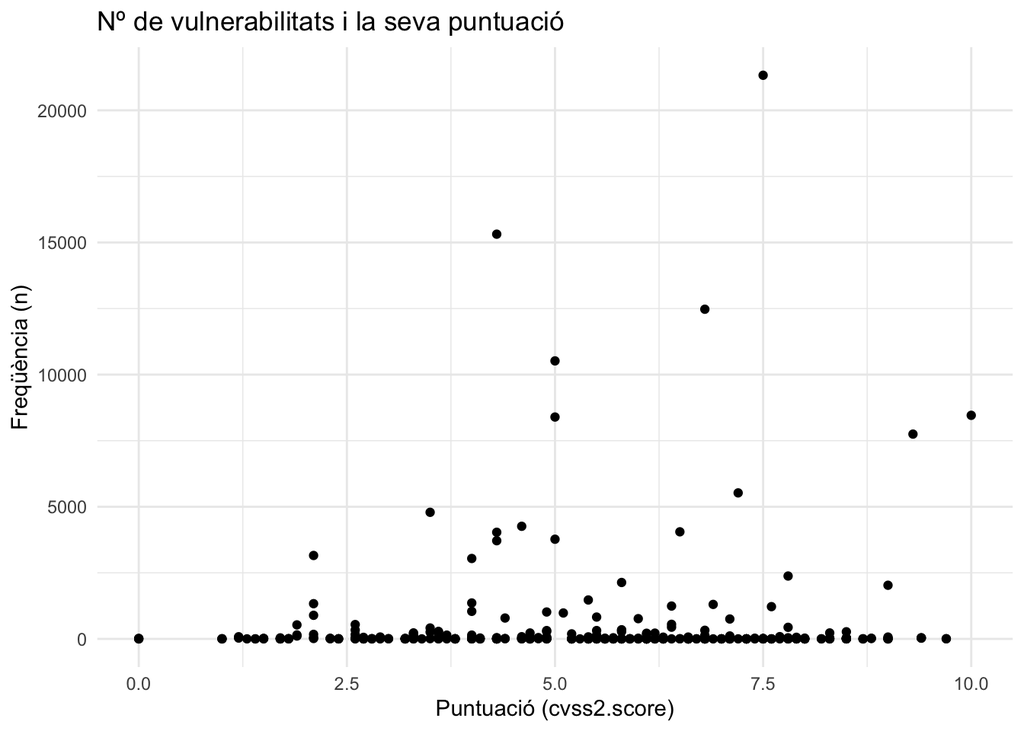

```r
df_cves_plot1 <- ggplot(df_cves, aes(x=cvss2.score, y=nº)) +
  geom_point(stat="identity", fill="steelblue") +
  ggtitle ("Nº de vulnerabilitats i la seva puntuació") +
  xlab("Puntuació (cvss2.score)") + ylab("Freqüència (n)") +
  theme_minimal()

print(df_cves_plot1)
```

*Nota: S’han relacionat els estàndards CWE i CVE amb el dataset d’incidents. No obstant, aquests dos dataframe s’interrelacionen amb les tècniques d’ATT$CK, on podria ser interessant l’anàlisi d’aquesta relació.*

```r
id_attck.techniques<- dplyr::select(attck.techniques,external_id, name, description)
id_attck.techniques.filter1 <- id_attck.techniques %>%
  filter(external_id == "T1072" | external_id == "T1078");

id_attck.relations<- select(attck.relations,from, to )
id_attck.relations.filter1<- filter(id_attck.relations, id_attck.relations$to == "T1072" | id_attck.relations$to == "T1078")
```

## 4. ¿Qui està darrera els atacs?

En primer lloc, per poder veure qui ha realitzat els atacs, s’estudien els grups que estàn relacionats amb les tècniques d’estudi. S’obtenen els diversos grups ciberdelinqüents a través *d’ATT&CK Groups*. Posteriorment es seleccionen els grups ciberdelinqüents que han utilitzat les tècniques **T1072** i **T1078** mitjançant dataset *d’ATT&CK techniques*. Els resultats es mostren a la taula a continuació:

```r
attck.techniques.from<- dplyr::select(attck.relations, from, to)
attck.techniques.filter1 <- attck.techniques.from %>%
filter(attck.techniques.from$to == "T1072" | attck.techniques.from$to == "T1078")

attck.techniques.filter2 <- filter(attck.techniques.filter1, startsWith(as.character(attck.techniques.filter1$from), "G"))

attck.techniques.count <- attck.techniques.filter2 %>%
  count(to)
attck.groups.from <- dplyr::select(attck.groups, external_id, name, description)
colnames(attck.techniques.filter2) <- c("external_id", "Tècniques")

attck.merge<-merge(x=attck.groups.from,y=attck.techniques.filter2,by="external_id",all.x=TRUE)
attck.merge <- na.omit(attck.merge)
```

```r
kbl(attck.merge) %>%
  kable_classic_2(full_width = F)
```

|  | Mitre_ATT$CK Org | Nom Org. | Descripció | Tècnica utilitzada |
| --- | --- | --- | --- | --- |
| 7 | G0007 | APT28 | [APT28](https://attack.mitre.org/groups/G0007) is a threat group that has been attributed to Russia’s General Staff Main Intelligence Directorate (GRU) 85th Main Special Service Center (GTsSS) militar… | T1078 |
| 8 | G0008 | Carbanak | [Carbanak](https://attack.mitre.org/groups/G0008) is a threat group that mainly targets banks. It also refers to malware of the same name ([Carbanak](https://attack.mitre.org/software/S0030)). It is s… | T1078 |
| 11 | G0011 | PittyTiger | [PittyTiger](https://attack.mitre.org/groups/G0011) is a threat group believed to operate out of China that uses multiple different types of malware to maintain command and control. (Citation: Bizeul … | T1078 |
| 14 | G0014 | Night Dragon | [Night Dragon](https://attack.mitre.org/groups/G0014) is a campaign name for activity involving a threat group that has conducted activity originating primarily in China. (Citation: McAfee Night Drago… | T1078 |
| 16 | G0016 | APT29 | [APT29](https://attack.mitre.org/groups/G0016) is threat group that has been attributed to Russia’s Foreign Intelligence Service (SVR).(Citation: White House Imposing Costs RU Gov April 2021)(Citation… | T1078 |
| 26 | G0026 | APT18 | [APT18](https://attack.mitre.org/groups/G0026) is a threat group that has operated since at least 2009 and has targeted a range of industries, including technology, manufacturing, human rights groups,… | T1078 |
| 27 | G0027 | Threat Group-3390 | [Threat Group-3390](https://attack.mitre.org/groups/G0027) is a Chinese threat group that has extensively used strategic Web compromises to target victims. (Citation: Dell TG-3390) The group has been … | T1078 |
| 28 | G0028 | Threat Group-1314 | [Threat Group-1314](https://attack.mitre.org/groups/G0028) is an unattributed threat group that has used compromised credentials to log into a victim’s remote access infrastructure. (Citation: Dell TG… | T1072 |
| 34 | G0034 | Sandworm Team | [Sandworm Team](https://attack.mitre.org/groups/G0034) is a destructive threat group that has been attributed to Russia’s General Staff Main Intelligence Directorate (GRU) Main Center for Special Tech… | T1078 |
| 37 | G0037 | FIN6 | [FIN6](https://attack.mitre.org/groups/G0037) is a cyber crime group that has stolen payment card data and sold it for profit on underground marketplaces. This group has aggressively targeted and comp… | T1078 |
| 39 | G0039 | Suckfly | [Suckfly](https://attack.mitre.org/groups/G0039) is a China-based threat group that has been active since at least 2014. (Citation: Symantec Suckfly March 2016) | T1078 |
| 44 | G0045 | menuPass | [menuPass](https://attack.mitre.org/groups/G0045) is a threat group that has been active since at least 2006. Individual members of [menuPass](https://attack.mitre.org/groups/G0045) are known to have … | T1078 |
| 48 | G0049 | OilRig | [OilRig](https://attack.mitre.org/groups/G0049) is a suspected Iranian threat group that has targeted Middle Eastern and international victims since at least 2014. The group has targeted a variety of … | T1078 |
| 49 | G0050 | APT32 | [APT32](https://attack.mitre.org/groups/G0050) is a threat group that has been active since at least 2014. The group has targeted multiple private sector industries as well as with foreign governments… | T1072 |
| 50 | G0051 | FIN10 | [FIN10](https://attack.mitre.org/groups/G0051) is a financially motivated threat group that has targeted organizations in North America since at least 2013 through 2016. The group uses stolen data exf… | T1078 |
| 52 | G0053 | FIN5 | [FIN5](https://attack.mitre.org/groups/G0053) is a financially motivated threat group that has targeted personally identifiable information and payment card information. The group has been active sinc… | T1078 |
| 58 | G0061 | FIN8 | [FIN8](https://attack.mitre.org/groups/G0061) is a financially motivated threat group known to launch tailored spearphishing campaigns targeting the retail, restaurant, and hospitality industries. (Ci… | T1078 |
| 61 | G0064 | APT33 | [APT33](https://attack.mitre.org/groups/G0064) is a suspected Iranian threat group that has carried out operations since at least 2013. The group has targeted organizations across multiple industries … | T1078 |
| 62 | G0065 | Leviathan | [Leviathan](https://attack.mitre.org/groups/G0065) is a cyber espionage group that has been active since at least 2013. The group generally targets defense and government organizations, but has also t… | T1078 |
| 71 | G0074 | Dragonfly 2.0 | [Dragonfly 2.0](https://attack.mitre.org/groups/G0074) is a suspected Russian group that has targeted government entities and multiple U.S. critical infrastructure sectors since at least December 2015… | T1078 |
| 82 | G0085 | FIN4 | [FIN4](https://attack.mitre.org/groups/G0085) is a financially-motivated threat group that has targeted confidential information related to the public financial market, particularly regarding healthca… | T1078 |
| 84 | G0087 | APT39 | [APT39](https://attack.mitre.org/groups/G0087) is one of several names for cyberespionage activity conducted by the Iranian Ministry of Intelligence and Security (MOIS) through the front company Rana … | T1078 |
| 85 | G0088 | TEMP.Veles | [TEMP.Veles](https://attack.mitre.org/groups/G0088) is a Russia-based threat group that has targeted critical infrastructure. The group has been observed utilizing TRITON, a malware framework designed… | T1078 |
| 88 | G0091 | Silence | [Silence](https://attack.mitre.org/groups/G0091) is a financially motivated threat actor targeting financial institutions in different countries. The group was first seen in June 2016. Their main targ… | T1072 |
| 89 | G0091 | Silence | [Silence](https://attack.mitre.org/groups/G0091) is a financially motivated threat actor targeting financial institutions in different countries. The group was first seen in June 2016. Their main targ… | T1078 |
| 91 | G0093 | GALLIUM | [GALLIUM](https://attack.mitre.org/groups/G0093) is a group that has been active since at least 2012, primarily targeting high-profile telecommunications networks. [GALLIUM](https://attack.mitre.org/g… | T1078 |
| 94 | G0096 | APT41 | [APT41](https://attack.mitre.org/groups/G0096) is a threat group that researchers have assessed as Chinese state-sponsored espionage group that also conducts financially-motivated operations. [APT41](… | T1078 |
| 99 | G0102 | Wizard Spider | [Wizard Spider](https://attack.mitre.org/groups/G0102) is a financially motivated criminal group that has been conducting ransomware campaigns since at least August 2018 against a variety of organizat… | T1078 |
| 107 | G0114 | Chimera | [Chimera](https://attack.mitre.org/groups/G0114) is a suspected China-based threat group that has been active since at least 2018 targeting the semiconductor industry in Taiwan as well as data from th… | T1078 |
| 109 | G0116 | Operation Wocao | [Operation Wocao](https://attack.mitre.org/groups/G0116) described activities carried out by a China-based cyber espionage adversary. [Operation Wocao](https://attack.mitre.org/groups/G0116) targeted … | T1078 |
| 110 | G0117 | Fox Kitten | [Fox Kitten](https://attack.mitre.org/groups/G0117) is threat actor with a suspected nexus to the Iranian government that has been active since at least 2017 against entities in the Middle East, North… | T1078 |
| 114 | G0122 | Silent Librarian | [Silent Librarian](https://attack.mitre.org/groups/G0122) is a group that has targeted research and proprietary data at universities, government agencies, and private sector companies worldwide since … | T1078 |

## 5. Com es varen realitzar els atacs?

```r
attck.tactics.how<- dplyr::select(attck.tactics, name, description, external_id)
attck.tactics.how.filter<- filter(attck.tactics.how, attck.tactics.how$name == "Execution" | attck.tactics.how$name == "Lateral Movement"| attck.tactics.how$name == "Defense Evasion" | attck.tactics.how$name == "Persistence" | attck.tactics.how$name == "Privilege Escalation," | attck.tactics.how$name == "Initial Access")
```

```r
library(kableExtra)
  kbl(attck.tactics.how) %>%
  kable_classic_2(full_width = F)
```

name

description

external_id

Collection

The adversary is trying to gather data of interest to their goal.

Collection consists of techniques adversaries may use to gather information and the sources information is collected from that are relevant to following through on the adversary’s objectives. Frequently, the next goal after collecting data is to steal (exfiltrate) the data. Common target sources include various drive types, browsers, audio, video, and email. Common collection methods include capturing screenshots and keyboard input.

TA0009

Command and Control

The adversary is trying to communicate with compromised systems to control them.

Command and Control consists of techniques that adversaries may use to communicate with systems under their control within a victim network. Adversaries commonly attempt to mimic normal, expected traffic to avoid detection. There are many ways an adversary can establish command and control with various levels of stealth depending on the victim’s network structure and defenses.

TA0011

Credential Access

The adversary is trying to steal account names and passwords.

Credential Access consists of techniques for stealing credentials like account names and passwords. Techniques used to get credentials include keylogging or credential dumping. Using legitimate credentials can give adversaries access to systems, make them harder to detect, and provide the opportunity to create more accounts to help achieve their goals.

TA0006

Defense Evasion

The adversary is trying to avoid being detected.

Defense Evasion consists of techniques that adversaries use to avoid detection throughout their compromise. Techniques used for defense evasion include uninstalling/disabling security software or obfuscating/encrypting data and scripts. Adversaries also leverage and abuse trusted processes to hide and masquerade their malware. Other tactics’ techniques are cross-listed here when those techniques include the added benefit of subverting defenses.

TA0005

Discovery

The adversary is trying to figure out your environment.

Discovery consists of techniques an adversary may use to gain knowledge about the system and internal network. These techniques help adversaries observe the environment and orient themselves before deciding how to act. They also allow adversaries to explore what they can control and what’s around their entry point in order to discover how it could benefit their current objective. Native operating system tools are often used toward this post-compromise information-gathering objective.

TA0007

Execution

The adversary is trying to run malicious code.

Execution consists of techniques that result in adversary-controlled code running on a local or remote system. Techniques that run malicious code are often paired with techniques from all other tactics to achieve broader goals, like exploring a network or stealing data. For example, an adversary might use a remote access tool to run a PowerShell script that does Remote System Discovery.

TA0002

Exfiltration

The adversary is trying to steal data.

Exfiltration consists of techniques that adversaries may use to steal data from your network. Once they’ve collected data, adversaries often package it to avoid detection while removing it. This can include compression and encryption. Techniques for getting data out of a target network typically include transferring it over their command and control channel or an alternate channel and may also include putting size limits on the transmission.

TA0010

Impact

The adversary is trying to manipulate, interrupt, or destroy your systems and data.

Impact consists of techniques that adversaries use to disrupt availability or compromise integrity by manipulating business and operational processes. Techniques used for impact can include destroying or tampering with data. In some cases, business processes can look fine, but may have been altered to benefit the adversaries’ goals. These techniques might be used by adversaries to follow through on their end goal or to provide cover for a confidentiality breach.

TA0040

Initial Access

The adversary is trying to get into your network.

Initial Access consists of techniques that use various entry vectors to gain their initial foothold within a network. Techniques used to gain a foothold include targeted spearphishing and exploiting weaknesses on public-facing web servers. Footholds gained through initial access may allow for continued access, like valid accounts and use of external remote services, or may be limited-use due to changing passwords.

TA0001

Lateral Movement

The adversary is trying to move through your environment.

Lateral Movement consists of techniques that adversaries use to enter and control remote systems on a network. Following through on their primary objective often requires exploring the network to find their target and subsequently gaining access to it. Reaching their objective often involves pivoting through multiple systems and accounts to gain. Adversaries might install their own remote access tools to accomplish Lateral Movement or use legitimate credentials with native network and operating system tools, which may be stealthier.

TA0008

Persistence

The adversary is trying to maintain their foothold.

Persistence consists of techniques that adversaries use to keep access to systems across restarts, changed credentials, and other interruptions that could cut off their access. Techniques used for persistence include any access, action, or configuration changes that let them maintain their foothold on systems, such as replacing or hijacking legitimate code or adding startup code.

TA0003

Privilege Escalation

The adversary is trying to gain higher-level permissions.

Privilege Escalation consists of techniques that adversaries use to gain higher-level permissions on a system or network. Adversaries can often enter and explore a network with unprivileged access but require elevated permissions to follow through on their objectives. Common approaches are to take advantage of system weaknesses, misconfigurations, and vulnerabilities. Examples of elevated access include:

- SYSTEM/root level
- local administrator
- user account with admin-like access
- user accounts with access to specific system or perform specific function

These techniques often overlap with Persistence techniques, as OS features that let an adversary persist can execute in an elevated context.

TA0004

Reconnaissance

The adversary is trying to gather information they can use to plan future operations.

Reconnaissance consists of techniques that involve adversaries actively or passively gathering information that can be used to support targeting. Such information may include details of the victim organization, infrastructure, or staff/personnel. This information can be leveraged by the adversary to aid in other phases of the adversary lifecycle, such as using gathered information to plan and execute Initial Access, to scope and prioritize post-compromise objectives, or to drive and lead further Reconnaissance efforts.

TA0043

Resource Development

The adversary is trying to establish resources they can use to support operations.

Resource Development consists of techniques that involve adversaries creating, purchasing, or compromising/stealing resources that can be used to support targeting. Such resources include infrastructure, accounts, or capabilities. These resources can be leveraged by the adversary to aid in other phases of the adversary lifecycle, such as using purchased domains to support Command and Control, email accounts for phishing as a part of Initial Access, or stealing code signing certificates to help with Defense Evasion.

TA0042

## 6. ¿Quin era el seu objectiu?

Mitjançant les tècniques trobades al dataset de l’estàndard **CAR**, s’extrauen els camps necessaris per a posteriorment confeccionar la taula on es mostrin els objectius juntament amb una descripció de cada un dels casos relacionat amb les dues tècniques d’estudi:

```r
car.coverage<- dplyr::select(car.coverage, from, to)
car.coverage<- filter(car.coverage, car.coverage$to == "T1072" | car.coverage$to == "T1078")
colnames(car.coverage)[which(names(car.coverage) == "from")] <- "id"
colnames(car.coverage)[which(names(car.coverage) == "Mitre.id Org_attck")] <- "Tècniques utilitzades"

car.analytics <- dplyr::select(car.analytics, id, title, description)

car.merge<-merge(x=car.coverage,y=car.analytics,by="id",all.x=TRUE)
car.merge = car.merge [ , c(1,3,4,2)]
```

```r
library(kableExtra)
  kbl(car.merge) %>%
  kable_classic_2(full_width = F)
```

id

title

description

to

CAR-2013-02-008

Simultaneous Logins on a Host

Multiple users logged into a single machine at the same time, or even within the same hour, do not typically occur in networks we have observed.

Logon events are Windows Event Code 4624 for Windows Vista and above, 518 for pre-Vista. Logoff events are 4634 for Windows Vista and above, 538 for pre-Vista. Logon types 2, 3, 9 and 10 are of interest. For more details see the Logon Types table on Microsoft’s Audit Logon Events page.

T1078

CAR-2013-02-012

User Logged in to Multiple Hosts

Most users use only one or two machines during the normal course of business. User accounts that log in to multiple machines, especially over a short period of time, may be compromised. Remote logins among multiple machines may be an indicator of [Lateral Movement](https://attack.mitre.org/tactics/TA0008).

Certain users will likely appear as being logged into several machines and may need to be “whitelisted.” Such users would include network admins or user names that are common to many hosts.

### Output Description

User Name, Machines logged into, the earliest and latest times in which users were logged into the host, the type of logon, and logon ID.

T1078

CAR-2013-05-003

SMB Write Request

As described in CAR-2013-01-003, SMB provides a means of remotely managing a file system. Adversaries often use SMB to move laterally to a host. SMB is commonly used to upload files. It may be used for staging in [Exfiltration](https://attack.mitre.org/tactics/TA0010) or as a [Lateral Movement](https://attack.mitre.org/tactics/TA0008) technique. Unlike SMB Reads, SMB Write requests typically require an additional level of access, resulting in less activity. Focusing on SMB Write activity narrows the field to find techniques that actively change remote hosts, instead of passively reading files.

T1078

CAR-2013-05-005

SMB Copy and Execution

An adversary needs to gain access to other hosts to move throughout an environment. In many cases, this is a twofold process. First, a file is remotely written to a host via an SMB share (detected by CAR-2013-05-003). Then, a variety of [Execution](https://attack.mitre.org/tactics/TA0002) techniques can be used to remotely establish execution of the file or script. To detect this behavior, look for files that are written to a host over SMB and then later run directly as a process or in the command line arguments. SMB File Writes and Remote Execution may happen normally in an environment, but the combination of the two behaviors is less frequent and more likely to indicate adversarial activity.

This can possibly extend to more copy protocols in order to widen its reach, or it could be tuned more finely to focus on specific program run locations (e.g. `%SYSTEMROOT%\system32`) to gain a higher detection rate.

T1078

CAR-2013-10-001

User Login Activity Monitoring

Monitoring logon and logoff events for hosts on the network is very important for situational awareness. This information can be used as an indicator of unusual activity as well as to corroborate activity seen elsewhere.

Could be applied to a number of different types of monitoring depending on what information is desired. Some use cases include monitoring for all remote connections and building login timelines for users. Logon events are Windows Event Code 4624 for Windows Vista and above, 518 for pre-Vista. Logoff events are 4634 for Windows Vista and above, 538 for pre-Vista.

### Output Description

The time of login events for distinct users on individual systems

T1078

## 7. ¿Com ens podem protegir?

```r
shield.relations <- select(shield.relations, from, to)
shield.relations.filter <- filter(shield.relations,shield.relations$to == "DTE0017" | as.character(shield.relations$to) == "DTE008" | as.character(shield.relations$to) == "DTE0010"| as.character(shield.relations$to) == "DTE0012")
colnames(shield.relations.filter)[which(names(shield.relations.filter) == "to")] <- "id"

shield.merge<-merge(x=shield.techniques,y=shield.relations.filter,by="id",all.x=TRUE)
shield.merge <- na.omit(shield.merge)
```

```r
library(kableExtra)
  kbl(shield.merge) %>%
  kable_classic_2(full_width = F)
```

|  | id | name | description | long_description | from |
| --- | --- | --- | --- | --- | --- |
| 8 | DTE0010 | Decoy Account | Create an account that is used for active defense purposes. | A decoy account is one that is created specifically for defensive or deceptive purposes. It can be in the form of user accounts, service accounts, software accounts, etc. The decoy account can be used… | DTA0001 |
| 9 | DTE0010 | Decoy Account | Create an account that is used for active defense purposes. | A decoy account is one that is created specifically for defensive or deceptive purposes. It can be in the form of user accounts, service accounts, software accounts, etc. The decoy account can be used… | DTA0008 |
| 10 | DTE0010 | Decoy Account | Create an account that is used for active defense purposes. | A decoy account is one that is created specifically for defensive or deceptive purposes. It can be in the form of user accounts, service accounts, software accounts, etc. The decoy account can be used… | DTA0003 |
| 11 | DTE0010 | Decoy Account | Create an account that is used for active defense purposes. | A decoy account is one that is created specifically for defensive or deceptive purposes. It can be in the form of user accounts, service accounts, software accounts, etc. The decoy account can be used… | DTA0002 |
| 12 | DTE0010 | Decoy Account | Create an account that is used for active defense purposes. | A decoy account is one that is created specifically for defensive or deceptive purposes. It can be in the form of user accounts, service accounts, software accounts, etc. The decoy account can be used… | DTA0007 |
| 13 | DTE0010 | Decoy Account | Create an account that is used for active defense purposes. | A decoy account is one that is created specifically for defensive or deceptive purposes. It can be in the form of user accounts, service accounts, software accounts, etc. The decoy account can be used… | DTA0004 |
| 14 | DTE0010 | Decoy Account | Create an account that is used for active defense purposes. | A decoy account is one that is created specifically for defensive or deceptive purposes. It can be in the form of user accounts, service accounts, software accounts, etc. The decoy account can be used… | DTA0006 |
| 16 | DTE0012 | Decoy Credentials | Create user credentials that are used for active defense purposes. | Seed a target system with credentials (such as username/password, browser tokens, and other forms of authentication data) for the purpose of engagement. Decoy credentials can be planted in many locati… | DTA0002 |
| 17 | DTE0012 | Decoy Credentials | Create user credentials that are used for active defense purposes. | Seed a target system with credentials (such as username/password, browser tokens, and other forms of authentication data) for the purpose of engagement. Decoy credentials can be planted in many locati… | DTA0001 |
| 18 | DTE0012 | Decoy Credentials | Create user credentials that are used for active defense purposes. | Seed a target system with credentials (such as username/password, browser tokens, and other forms of authentication data) for the purpose of engagement. Decoy credentials can be planted in many locati… | DTA0004 |
| 19 | DTE0012 | Decoy Credentials | Create user credentials that are used for active defense purposes. | Seed a target system with credentials (such as username/password, browser tokens, and other forms of authentication data) for the purpose of engagement. Decoy credentials can be planted in many locati… | DTA0005 |
| 20 | DTE0012 | Decoy Credentials | Create user credentials that are used for active defense purposes. | Seed a target system with credentials (such as username/password, browser tokens, and other forms of authentication data) for the purpose of engagement. Decoy credentials can be planted in many locati… | DTA0006 |
| 21 | DTE0012 | Decoy Credentials | Create user credentials that are used for active defense purposes. | Seed a target system with credentials (such as username/password, browser tokens, and other forms of authentication data) for the purpose of engagement. Decoy credentials can be planted in many locati… | DTA0008 |
| 22 | DTE0012 | Decoy Credentials | Create user credentials that are used for active defense purposes. | Seed a target system with credentials (such as username/password, browser tokens, and other forms of authentication data) for the purpose of engagement. Decoy credentials can be planted in many locati… | DTA0007 |
| 27 | DTE0017 | Decoy System | Configure a computing system to serve as an attack target or experimental environment. | A decoy system is a computing resource presented to the adversary in support of active defense. The underlying system can be real, virtual, or simulated, and can be presented as one of a variety of IT… | DTA0002 |
| 28 | DTE0017 | Decoy System | Configure a computing system to serve as an attack target or experimental environment. | A decoy system is a computing resource presented to the adversary in support of active defense. The underlying system can be real, virtual, or simulated, and can be presented as one of a variety of IT… | DTA0004 |
| 29 | DTE0017 | Decoy System | Configure a computing system to serve as an attack target or experimental environment. | A decoy system is a computing resource presented to the adversary in support of active defense. The underlying system can be real, virtual, or simulated, and can be presented as one of a variety of IT… | DTA0007 |
| 30 | DTE0017 | Decoy System | Configure a computing system to serve as an attack target or experimental environment. | A decoy system is a computing resource presented to the adversary in support of active defense. The underlying system can be real, virtual, or simulated, and can be presented as one of a variety of IT… | DTA0006 |
| 31 | DTE0017 | Decoy System | Configure a computing system to serve as an attack target or experimental environment. | A decoy system is a computing resource presented to the adversary in support of active defense. The underlying system can be real, virtual, or simulated, and can be presented as one of a variety of IT… | DTA0001 |
| 32 | DTE0017 | Decoy System | Configure a computing system to serve as an attack target or experimental environment. | A decoy system is a computing resource presented to the adversary in support of active defense. The underlying system can be real, virtual, or simulated, and can be presented as one of a variety of IT… | DTA0008 |

## 8. ¿Què podem fer per prevenir futurs atacs?

```r
attck.mitigations<- dplyr::select(attck.mitigations, external_id, name, description)
attck.techniques.filter4 <- filter(attck.techniques.filter1, startsWith(as.character(attck.techniques.filter1$from), "M"))
colnames(attck.mitigations)[which(names(attck.mitigations) == "external_id")] <- "from"

mitigations.merge<-merge(x=attck.mitigations,y=attck.techniques.filter4,by="from",all.x=TRUE)
mitigations.merge <- na.omit(mitigations.merge)
```

A través del dataset *Mitigations* d’ATT$CK es mostra una taula on s’aprecia una descripció del conjunt de tècniques de mitigació tot relacionant-ho amb les dues tècniques d’estudi.

```r
library(kableExtra)
  kbl(mitigations.merge) %>%
  kable_classic_2(full_width = F)
```

|  | from | name | description | to |
| --- | --- | --- | --- | --- |
| 1 | M1013 | Application Developer Guidance | This mitigation describes any guidance or training given to developers of applications to avoid introducing security weaknesses that an adversary may be able to take advantage of. | T1078 |
| 2 | M1015 | Active Directory Configuration | Configure Active Directory to prevent use of certain techniques; use SID Filtering, etc. | T1072 |
| 4 | M1017 | User Training | Train users to be aware of access or manipulation attempts by an adversary to reduce the risk of successful spearphishing, social engineering, and other techniques that involve user interaction. | T1072 |
| 5 | M1018 | User Account Management | Manage the creation, modification, use, and permissions associated to user accounts. | T1072 |
| 12 | M1026 | Privileged Account Management | Manage the creation, modification, use, and permissions associated to privileged accounts, including SYSTEM and root. | T1078 |
| 13 | M1026 | Privileged Account Management | Manage the creation, modification, use, and permissions associated to privileged accounts, including SYSTEM and root. | T1072 |
| 14 | M1027 | Password Policies | Set and enforce secure password policies for accounts. | T1072 |
| 15 | M1027 | Password Policies | Set and enforce secure password policies for accounts. | T1078 |
| 17 | M1029 | Remote Data Storage | Use remote security log and sensitive file storage where access can be controlled better to prevent exposure of intrusion detection log data or sensitive information. | T1072 |
| 18 | M1030 | Network Segmentation | Architect sections of the network to isolate critical systems, functions, or resources. Use physical and logical segmentation to prevent access to potentially sensitive systems and information. Use a … | T1072 |
| 20 | M1032 | Multi-factor Authentication | Use two or more pieces of evidence to authenticate to a system; such as username and password in addition to a token from a physical smart card or token generator. | T1072 |
| 39 | M1051 | Update Software | Perform regular software updates to mitigate exploitation risk. | T1072 |

## 9. ¿Seria possible predir atacs?

Seria possible si es realitzés un model de predicció de possibles ciberatacs. Mitjançant aquest model, es podrien processar els esdeveniments de ciberseguretat capturats a través dels sistemes de detecció informàtics per tal de generar una projecció futura de la probabilitat que es consolidi un atac. Tenint aquesta informació, els administradors de sistemes podrien prendre decisions essencials sobre com actuar davant d’imminents atacs informàtics.